# KNN Classifier and PCA

## KNN Classifier and PCA

```python
from google.colab import drive
drive.mount('/content/drive', force_remount=True)
```

```python
pip install python_speech_features
```

```python
# you can add further imports if you want
import numpy as np
import python_speech_features as psf
import librosa
import matplotlib.pyplot as plt
from sklearn.datasets import make_blobs

import glob
import os
from math import sqrt
import random
```

# Part 1: Feature Extraction

You will use the [MNIST audio dataset](https://www.kaggle.com/datasets/sripaadsrinivasan/audio-mnist?resource=download). It is an open source dataset and you can download it from kaggle.

- The dataset consists of 30000 audio samples of spoken digits (0-9) of 60 folders and 500 files each.
- There is one directory per speaker holding the audio recordings.
- Additionally "audioMNIST_meta.txt" provides meta information such as gender or age of each speaker.

Use the following line of code to load the audio files

[output not shown]

You will use the MFCC features for representing the audio.  
MFCCs are a common feature representation for audio classification in machine learning. They capture the spectral envelope of the sound by converting the audio signal to the frequency domain, applying a Mel-scale filterbank, taking the logarithm of the filterbank energies and applying DCT. This results in a compact, low-dimensional representation that captures important spectral information and is used as input features for training models for tasks such as speech recognition, music genre classification and sound event detection.  
Dont worry if none of this makes any sense, you can still use them as your features. But if you want to understand them in more detail you can read about them from [here](https://medium.com/@tanveer9812/mfccs-made-easy-7ef383006040).  
Length of each feature vector will be $n$, where $n$ is the number of mfcc features (out of a total of 40) you decide to use.  
Your dataset will be a $m \times (n+1$) matrix, where each row will represent an audio file and each column wil represent 1 feature. The last column will be the label of the digit spoken.

```python
# Use this code to extract MFCC features from audio file

def get_MFCC(audio, sr, numFeatures):
    features = psf.mfcc(audio, sr, 0.025, 0.01, numFeatures, appendEnergy = True)
    return np.mean(features, axis=0)
```

```python
# create your data matrix

### YOUR CODE HERE ###

files = []
matrix = []
trainingD = []
testingD = []
label = []
numFeatures=23 #taking 23 features

files = glob.glob("/content/drive/MyDrive/dataa/0*/*.wav")
#files = glob.glob("/content/drive/MyDrive/dataa/*/*.wav")
for f in files:
    head, tail = os.path.split(f)
    audio, sr = librosa.load(f, sr=16000)
    matrix.append(np.append(get_MFCC(audio, sr, numFeatures), int(tail[0]))) #MAKING M x (N+1) matrix

#Converting into matrix
trainingD = np.array(matrix)

print("Data Matrix")
print (trainingD) #FOR PRINITNG MATRIX

#SPLITTING DATA INTO TESTING AND TRAINING DATA
tsd = round(len(trainingD)*20/100)
#RANDOMIZE SLECTION
indexes = random.sample(range(0, len(trainingD)),tsd)

for i in indexes:
    testingD.append(trainingD[i])
    np.delete(trainingD, i)

print("Testing and Traing matrices")
print (len(testingD), len(testingD[0])) #FOR PRINITNG SIZE OF MATRIX
print (len(trainingD), len(trainingD[0])) #FOR PRINITNG SIZE OF MATRIX
```

[output not shown]

- Extract the label of the digit from the file name  
  *After loading all files with their labels, do a Test-Train Split of your choice

#### *Question: The features we get here are numerical, what if we also had categorical features e.g., even vs odd digit. How would knn deal with those?*

Ans: Since the classifier works on the basis of finding minimal distance between two points, it does not matter if the data is numerical or categorical. In case of ordinal data if a distance function, that relates data points by defining "closer" and "farther" unit(s), can be generated then using KNN for ordinal data is same as using it for numerical data.

# Part 2: Implement K-NN classifier from scratch

The goal of this assignment is to get you familiar with k-NN classification and to give hands on experience of basic python tools and libraries which will be used in implementing the algorithm. You are **not** allowed to use scikit-learn or any other machine learning toolkit for this part. You have to implement your own k-NN classifier from scratch. You may use Pandas, NumPy, Matplotlib and other standard python libraries.

### TASK 1:

Create your own k-Nearest Neighbors classifier function by performing following tasks:

- For a test data point, find its distance from all training instances.
- Sort the calculated distances in ascending order based on distance values.
- Choose k training samples with minimum distances from the test data point.
- Return the most frequent class of these samples. (Incase of ties, break them by backing off to k-1 values. For example, for a particular audio, incase of k=4, if you get two '3' labels and two '7' labels you will break tie by backing off to k=3. If tie occurs again you will keep backing off until tie is broken or you reach k=1.)
- Note: Your function should work with Euclidean distance as well as Manhattan distance. Pass the distance metric as a parameter in k-NN classifier function. Your function should also be general enough to work with any value of k.

```python
def euclidean_distance(row1, row2):
    return np.linalg.norm(row1 - row2)

def manhattan_distance(row1, row2):
    return sum(abs(val1-val2) for val1, val2 in zip(row1,row2))
```

```python
from collections import Counter

def my_mode(sample):
    c = Counter(sample)
    return [k for k, v in c.items() if v == c.most_common(1)[0][1]]
```

```python
def custom_knn(testDataPoint, distanceMetric, k):

  distanceMatrix = []
  NNLabel = []
  flag = True
  positives=0
  negatives=0

  for row in trainingD: #CALCULATING DISTANCES
    if distanceMetric == "Euclidean":
      distanceMatrix.append(euclidean_distance(testDataPoint[0:numFeatures], row[0:numFeatures]))
    elif distanceMetric == "Manhattan":
      distanceMatrix.append(manhattan_distance(testDataPoint[0:numFeatures], row[0:numFeatures]))
    else:
      print("Please enter 'Euclidean' or 'Manhattan'")

  while flag == True and k>=1: #INCASE OF TIES, break them by backing off to k-1 value
    for x in range(k): #CALCULATING K NEAREST NEIGHBORS
      NN = (np.argsort(distanceMatrix))[x]#GETTING K-TH ROW FROM MATRIX
      NNLabel.append(int((trainingD[NN])[numFeatures])) #GETTING CORRESPOBDING LABELS FROM TRAINING DATA
      if int((trainingD[NN])[numFeatures])== int(testDataPoint[numFeatures]):
        positives=positives+1
      if int((trainingD[NN])[numFeatures]) != int(testDataPoint[numFeatures]):
        negatives=negatives+1

      #print((np.argsort(distanceMatrix))[x])
      #print((trainingD[NN])[numFeatures])
    if len(my_mode(NNLabel)) > 1 :
      flag = True
      k=k-1
    else:
      flag = False
  #print(NNLabel)
  return my_mode(NNLabel)[0],positives,negatives
```

```python
print(positives)
print(negatives)
```

```
0
0
```

### TASK 2:

Run your k-NN function for different values of k (atleast three) on test data. Do this for both the Euclidean distance and the Manhattan distance for each value of k. Plot three graphs displaying following:

- k-values vs accuracy for both euclidean and manhattan distance (k-values on x-axis and accuracy values on y-axis)
- k-values vs macro-average precision for both euclidean and manhattan distance (k-values on x-axis and precision values on y-axis)
- k-values vs macro-average recall for both euclidean and manhattan distance (k-values on x-axis and recall values on y-axis)

All of your graphs should be properly labelled.

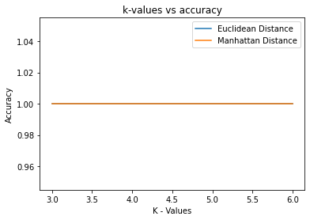

```python
### YOUR CODE HERE ###
import matplotlib.pyplot as plt

prediction,positives,negatives = custom_knn((testingD[0]), "Euclidean", 3)
k3Ecu = positives/positives+negatives

prediction,positives,negatives = custom_knn((testingD[0]), "Manhattan", 3)
k3Man = positives/positives+negatives

prediction,positives,negatives = custom_knn((testingD[0]), "Euclidean", 4)
k4Ecu = positives/positives+negatives

prediction,positives,negatives = custom_knn((testingD[0]), "Manhattan", 4)
k4Man = positives/positives+negatives

prediction,positives,negatives = custom_knn((testingD[0]), "Euclidean", 5)
k5Ecu = positives/positives+negatives

prediction,positives,negatives = custom_knn((testingD[0]), "Manhattan", 5)
k5Man = positives/positives+negatives

prediction,positives,negatives = custom_knn((testingD[0]), "Euclidean", 6)
k6Ecu = positives/positives+negatives

prediction,positives,negatives = custom_knn((testingD[0]), "Manhattan", 6)
k6Man = positives/positives+negatives



# Euclidean points
x1 = [3,4,5,6]
y1 = [k3Ecu,k4Ecu,k5Ecu,k6Ecu]
plt.plot(x1, y1, label = "Euclidean Distance")# plotting the Euclidean points

# Manhattan points
x2 = [3,4,5,6]
y2 = [k3Man,k4Man,k5Man,k6Man]
plt.plot(x2, y2, label = "Manhattan Distance")# plotting the Manhattan points

plt.xlabel('K - Values')# naming the x axis
plt.ylabel('Accuracy')# naming the y axis
plt.title('k-values vs accuracy')# giving a title to my graph
plt.legend()# show a legend on the plot
plt.show()# function to show the plot
```

```python
### YOUR CODE HERE ###
import matplotlib.pyplot as plt

k3Ecu = custom_knn((testingD[0]), "Euclidean", 3)
k3Man = custom_knn((testingD[0]), "Manhattan", 3)

k4Ecu = custom_knn((testingD[0]), "Euclidean", 4)
k4Man = custom_knn((testingD[0]), "Manhattan", 4)

k5Ecu = custom_knn((testingD[0]), "Euclidean", 5)
k5Man = custom_knn((testingD[0]), "Manhattan", 5)

k6Ecu = custom_knn((testingD[0]), "Euclidean", 6)
k6Man = custom_knn((testingD[0]), "Manhattan", 6)

# Euclidean points
x1 = [3,4,5,6]
y1 = [k3Ecu,k4Ecu,k5Ecu,k6Ecu]
plt.plot(x1, y1, label = "Euclidean Distance")# plotting the Euclidean points

# Manhattan points
x2 = [3,4,5,6]
y2 = [k3Man,k4Man,k5Man,k6Man]
plt.plot(x2, y2, label = "Manhattan Distance")# plotting the Manhattan points

plt.xlabel('K - Values')# naming the x axis
plt.ylabel('macro-average precision')# naming the y axis
plt.title('k-values vs macro-average precision')# giving a title to my graph
plt.legend()# show a legend on the plot
plt.show()# function to show the plot
```

[output not shown]

```python
### YOUR CODE HERE ###
import matplotlib.pyplot as plt

k3Ecu = custom_knn((testingD[0]), "Euclidean", 3)
k3Man = custom_knn((testingD[0]), "Manhattan", 3)

k4Ecu = custom_knn((testingD[0]), "Euclidean", 4)
k4Man = custom_knn((testingD[0]), "Manhattan", 4)

k5Ecu = custom_knn((testingD[0]), "Euclidean", 5)
k5Man = custom_knn((testingD[0]), "Manhattan", 5)

k6Ecu = custom_knn((testingD[0]), "Euclidean", 6)
k6Man = custom_knn((testingD[0]), "Manhattan", 6)

# Euclidean points
x1 = [3,4,5,6]
y1 = [k3Ecu,k4Ecu,k5Ecu,k6Ecu]
plt.plot(x1, y1, label = "Euclidean Distance")# plotting the Euclidean points

# Manhattan points
x2 = [3,4,5,6]
y2 = [k3Man,k4Man,k5Man,k6Man]
plt.plot(x2, y2, label = "Manhattan Distance")# plotting the Manhattan points

plt.xlabel('K - Values')# naming the x axis
plt.ylabel('macro-average recall')# naming the y axis
plt.title('k-values vs macro-average recall')# giving a title to my graph
plt.legend()# show a legend on the plot
plt.show()# function to show the plot
```

[output not shown]

#### *Question: What is the best K according to accuracy, precision and recall? If you choose a different K for different metrics then comment on the difference between metrics.*

# Part 3: k-NN classifier using scikit-learn

### TASK 1:

In this part you have to use [scikit-learn’s k-NN implementation](https://scikit-learn.org/stable/modules/generated/sklearn.neighbors.KNeighborsClassifier.html) to train and test your classifier on the dataset used in Part 2. Run the k-NN classifier for values of k = 1, 2, 3, 4, 5, 6, 7 using both Euclidean and Manhattan distance. Use scikit-learn to calculate and print the accuracy, F1 score and confusion matrix for test data.  
Plot a graph with k values on x-axis and F1 score on y-axis for both distance metrics in a single plot.

#### *Question: What can we interpret from the F1 score that we can not from accuracy?*

Answer: ROC curve requires true positive (TP), true negative (TN), false positive (FP) and false negative (FN) points from the data. To get accuracy, we require TP and TN to figure out how "correct" the results are. For F1 score, we need FP and FN. f1 score is more crucial than accuracy since an FP, even comparatively smaller, can cause a major impact. For instance, if a patient is correctly predicted for not having cancer (TN) it means that the system is working accurately. But if the patient is wrongly predicted for not having cancer (FN) that would be a high risk.

### TASK 2:

For this task you have been given a synthetic dataset of 1000 samples which is divided into 6 classes. Visualization of this dataset has also been given. Now you need to find the optimum value of k for this dataset. This can be done using GridSearchCV function provided by Scikit-learn. This function allows us to check easily for multiple values of k. You need to check for all values of k and report the best value. Use any distance metric you wish, or you can also try to find which metric works best for you.

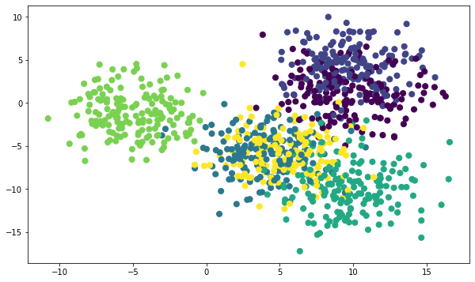

```python
X, y = make_blobs(n_samples = 1000, n_features = 2, centers = 6, cluster_std = 2.5, random_state = 4)
plt.figure(figsize=(10,6))
plt.scatter(X[:,0], X[:,1], c=y, marker= 'o', s=50)
plt.show()
```

```python
### YOUR CODE HERE ###
```

#### *Question: Why is standardization (feature scaling) required for KNN to work properly.*

Ans: Since KNN works on the basis of point to point distance, it is important that the data is standardized/normalized in order to have a consistent system to work with.

#### *Question: How does the choice of 'k' affect overfitting and underfitting?*

Ans: Value of K impacts the error rate hence a small value of k can cause the network to be overfit while a bigger k would mean the data can be underfit.

# Part 4: Principal Component Analysis

First you will have to implement PCA from scratch and visualize it on a simple 2-D dataset.

#### Dataset

Here is a synthetic dataset, the points are sampled from a Bivariate Gaussian Distribution

```
X.shape: (1000, 2)
```

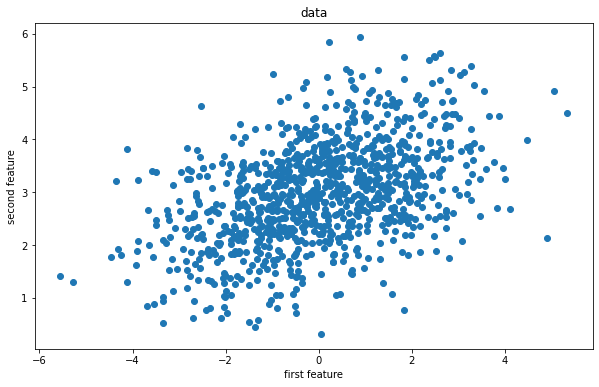

```python
#  We will generate a dataset with 2 features so we can plot and visualize it easily.
mean = [0, 3]                        #mean vector, mean[0] is the mean of the first feature, and mean[1] is the mean of the second feature.
cov = [[3, 0.8], [0.8, 1]]           #covariance matrix
n_samples = 1000
X = np.random.multivariate_normal(mean, cov, n_samples)
print('X.shape:', X.shape)

#visualize the dataset
plt.figure(figsize=(10, 6))
plt.scatter(X[:, 0], X[:, 1], marker= 'o')
plt.xlabel("first feature")
plt.ylabel("second feature")
plt.title("data")
plt.show()
```

###### Once done with the tasks, try different values of mean vector and the covariance matrix to try out different scenarios.

### Task 1: PCA from scratch

Create your own PCA function by performing the following tasks:-

- Standardize the data
- Compute the covariance matrix
- Compute EVD of the covariance matrix
- Sort the eigenvectors according to decreasing magnitude of eigenvalues
- Project data on the eigenvectors

```python
### YOUR CODE HERE ###

#Standardize the data

mean_feat1 = 0
mean_feat2 = 0
sum_feat1 = 0
sum_feat2 = 0
for x in X:
  sum_feat1 = sum_feat1 + x[0]
  sum_feat2 = sum_feat2 + x[1]

mean_feat1 = sum_feat1/1000
mean_feat2 = sum_feat2/1000

for x in range(len(X)):
 (X[x])[0] = (X[x])[0] - mean_feat1
 (X[x])[1] = (X[x])[1] - mean_feat2
```

### Task 2: Visualizing the Principle Components

Plot the principal components of the data before and after applying your PCA function.  
Plot these on the same graph with the data. Properly label your plots.

```python
### YOUR CODE HERE ###
```

### Task 3: Dimensionality Reduction

You should notice that untill now you have only transformed the data onto a different basis, however it is still in 2-D.

- Perform dimensionality reduction by projecting the data onto only the first eigenvector.

```python
### YOUR CODE HERE ###
```

### Task 4: Reconstructing Data and efficiency of PCA

- Reconstruct the original data from data projected onto the first PC (to reconstruct 2-D data use inverse PCA) and compute the reconstruction loss i.e., $||{X_{reconstructed} - X_{original}}||$. Where $|| \cdot{} ||$ is the L2-norm
- Now try a naive dimensionality reduction technique i.e., ignoring the second feature and compute the reconstruction loss again .
- Compare the two and explain the difference. Is there a case possible when they are equal?

```python
### YOUR CODE HERE ###
```

#### *Question: Briefly explain the curse of dimensionality and how PCA can be used to tackle it.*

Ans: Curse of dimensionality refers to increase in the set of features. If the features of data increse, it would in turn make the data sparse which would cause an overfit. Since PCA reduces dimension by projecting data onto orthognal axes, it can be used to tackle this curse.

# Part 5: Applying PCA to our problem

#### For this part you can use the PCA function you made in part 4 or implement it from any library.

Think of ways you can incorporate PCA into your implementation of KNN to classify mnist audio data. One idea that comes to mind is to extract a greater number of mfccs from the audio files and reduce them using PCA.  
If you believe that PCA will not be beneficial and you choose to not use it, justify your choice.

```python
### YOUR CODE HERE ###
```